# Make Models

B Steele, Colorado State University, ROSSyndicate

last updated Sep 1, 2026

This code trains XGBoost models to predict Secchi disk depth from Landsat surface reflectance for the 6-state regional dataset. We apply the AquaMatch cross-sensor corrections, engineer band-ratio spectral indices, split the partitioned dataset from script 03 into cross-validation and test sets, tune hyperparameters, train four leave-one-partition-out models, and evaluate performance on the held-out test partition.

## Setup

```r
# load libraries
library(tidyverse)
library(arrow)
library(xgboost)
library(Metrics)
library(igraph)
library(sf)
library(tmap)
library(tigris)
library(hydrogeofetch)

# read in the partitioned dataset from script 03
split_dataframes <- read_feather("aquamatch_files/split_filtered_regional.feather")
```

## Apply cross-sensor corrections

Landsat missions differ slightly in their band responses, so we apply Gardner et al.’s per-band quadratic correction coefficients (referenced to Landsat 7) to harmonize reflectance values across missions before deriving any indices.

```r
am_corr_LS7 <- read_csv("aquamatch_files/lakeSR_collated_handoffs_GEEv2025-02-12_QAv2025-06-04.csv") %>%
  filter(correction == "Gardner", dswe == "DSWE1", sat_to == "LS7") %>%
  # pivot for easier application
  pivot_longer(cols = c(intercept, B1, B2, min_in_val, max_in_val),
               names_to = "int_coef",
               values_to = "value") %>%
  mutate(new_column = paste(band, int_coef, sep = "_")) %>%
  select(-c(band, int_coef, slope, method)) %>%
  pivot_wider(names_from = new_column,
              values_from = value)
# apply coefficients to timeseries data
split_dataframes_corr <- split_dataframes %>%
  mutate(sat_corr = case_when(mission == "LT04" ~ "LS5", # landsat 4 is roughly the same as 5
                              mission == "LT05" ~ "LS5",
                              mission == "LE07" ~ "LS7",
                              mission == "LC08" ~ "LS8",
                              mission == "LC09" ~ "LS8", # landsat 9 is roughly the same as 8
                              TRUE ~ NA_character_),
         # LEDAPS atm correction for L4/5/7, LaSRC for L8/9
         atm_corr = case_when(mission %in% c("LT04", "LT05", "LE07") ~ "LEDAPS",
                              mission %in% c("LC08", "LC09") ~ "LaSRC",
                              TRUE ~ NA_character_),
         # numeric encoding for xgboost (LEDAPS as reference level)
         atm_corr_LaSRC = as.numeric(atm_corr == "LaSRC")) %>%
  left_join(., am_corr_LS7) %>%
  mutate(red_corr7 = med_Red_intercept + med_Red_B1*med_Red + med_Red_B2*med_Red^2,
         green_corr7 = med_Green_intercept + med_Green_B1*med_Green + med_Green_B2*med_Green^2,
         blue_corr7 = med_Blue_intercept + med_Blue_B1*med_Blue + med_Blue_B2*med_Blue^2,
         nir_corr7 = med_Nir_intercept + med_Nir_B1*med_Nir + med_Nir_B2*med_Nir^2,
         swir1_corr7 = med_Swir1_intercept + med_Swir1_B1*med_Swir1 + med_Swir1_B2*med_Swir1^2,
         swir2_corr7 = med_Swir2_intercept + med_Swir2_B1*med_Swir2 + med_Swir2_B2*med_Swir2^2) %>%
  # store ls7 in the corr7 column
  mutate(red_corr7 = if_else(sat_corr == "LS7", med_Red, red_corr7),
         green_corr7 = if_else(sat_corr == "LS7", med_Green, green_corr7),
         blue_corr7 = if_else(sat_corr == "LS7", med_Blue, blue_corr7),
         nir_corr7 = if_else(sat_corr == "LS7", med_Nir, nir_corr7),
         swir1_corr7 = if_else(sat_corr == "LS7", med_Swir1, swir1_corr7),
         swir2_corr7 = if_else(sat_corr == "LS7", med_Swir2, swir2_corr7)) %>%
  select(-c(all_of(names(am_corr_LS7))))
```

Do a quick plot to check that the correction seems right

```r
max_n_sites <- split_dataframes_corr %>%
  summarize(n = n(), .by = siteSR_id) %>%
  filter(n > 100) %>%
  left_join(split_dataframes_corr)
```

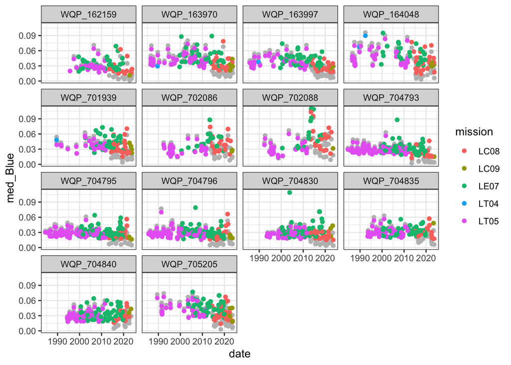

```r
ggplot() +
  geom_point(data = max_n_sites, aes(x = date, y = med_Blue), color = "grey") +
  geom_point(data = max_n_sites, aes(x = date, y = blue_corr7, color = mission))  +
  facet_wrap(siteSR_id ~ .) +
  theme_bw()
```

## Engineer spectral indices

Build band-ratio and normalized-difference features from the sensor-corrected bands for use as model predictors.

```r
split_dataframes_ml <- split_dataframes_corr %>%
  mutate(NR = nir_corr7/red_corr7,
         BR = blue_corr7/red_corr7,
         GR = green_corr7/red_corr7,
         SR = swir1_corr7/red_corr7,
         BG = blue_corr7/green_corr7,
         RG = red_corr7/green_corr7,
         NG = nir_corr7/green_corr7,
         SG = swir1_corr7/green_corr7,
         BN = blue_corr7/nir_corr7,
         GN = green_corr7/nir_corr7,
         RN = red_corr7/nir_corr7,
         SN = swir1_corr7/nir_corr7,
         BS = blue_corr7/swir1_corr7,
         GS = green_corr7/swir1_corr7,
         RS = red_corr7/swir1_corr7,
         NS = nir_corr7/swir1_corr7,
         R_GN = red_corr7/(green_corr7 + nir_corr7),
         R_GB = red_corr7/(green_corr7 + blue_corr7),
         R_GS = red_corr7/(green_corr7 + swir1_corr7),
         R_BN = red_corr7/(blue_corr7 + nir_corr7),
         R_BS = red_corr7/(blue_corr7 + swir1_corr7),
         R_NS = red_corr7/(nir_corr7 + swir1_corr7),
         G_BR = green_corr7/(blue_corr7 + swir1_corr7),
         G_BN = green_corr7/(blue_corr7 + nir_corr7),
         G_BS = green_corr7/(blue_corr7 + swir1_corr7),
         G_RN = green_corr7/(red_corr7 + nir_corr7),
         G_RB = green_corr7/(red_corr7 + blue_corr7),
         G_NS = green_corr7/(nir_corr7 + swir1_corr7),
         B_RG = blue_corr7/(red_corr7 + green_corr7),
         B_RS = blue_corr7/(red_corr7 + swir1_corr7),
         B_GN = blue_corr7/(green_corr7 + nir_corr7),
         B_GS = blue_corr7/(green_corr7 + swir1_corr7),
         B_NS = blue_corr7/(nir_corr7 + swir1_corr7),
         N_RG = nir_corr7/(red_corr7 + green_corr7),
         N_RB = nir_corr7/(red_corr7 + blue_corr7),
         N_RS = nir_corr7/(red_corr7 + swir1_corr7),
         N_GB = nir_corr7/(green_corr7 + blue_corr7),
         N_GS = nir_corr7/(green_corr7 + nir_corr7),
         N_BS = nir_corr7/(blue_corr7 + swir1_corr7),
         GR_2 = (red_corr7 + green_corr7)/2,
         GN_2 = (nir_corr7 + green_corr7)/2,
         BR_G = (blue_corr7 - red_corr7)/green_corr7,
         NS_NR = (nir_corr7 - swir1_corr7)/(red_corr7 - swir1_corr7),
         fai = nir_corr7 - (red_corr7 + (swir1_corr7 - red_corr7) * ((830-660)/(1650-660))),
         NmS = nir_corr7 - swir1_corr7,
         NmR = nir_corr7 - red_corr7,
         NDVI = (nir_corr7 - red_corr7)/(nir_corr7 + red_corr7),
         NDWI = (green_corr7 - swir1_corr7)/(green_corr7 + swir1_corr7),
         NDSSI = (blue_corr7 - nir_corr7)/(blue_corr7 + nir_corr7),
         GN_GN = (green_corr7- nir_corr7)/(green_corr7 + nir_corr7)) %>%
  # a handful of corrected bands land on exactly 0 (or two bands land on the
  # same value), which sends some ratio/difference features to Inf/NaN;
  # xgb.DMatrix() rejects those outright, so recode as NA and let xgboost's
  # native missing-value handling take it from there
  mutate(across(red_corr7:GN_GN, ~ if_else(is.finite(.x), .x, NA_real_)))
```

## Create train/validation/test splits

```r
train_val <- split_dataframes_ml %>%
  filter(part != 4)

train1 <- train_val %>%
  filter(part != 1)
val1 <- anti_join(train_val, train1)
```

[output not shown]

```r
train2 <- train_val %>%
  filter(part != 2)
val2 <- anti_join(train_val, train2)
```

[output not shown]

```r
train3 <- train_val %>%
  filter(part != 3)
val3 <- anti_join(train_val, train3)
```

[output not shown]

```r
train4<- train_val %>%
  filter(part != 5)
val4 <- anti_join(train_val, train4)
```

[output not shown]

Assemble the corrected bands and spectral indices as model features and build XGBoost DMatrices for each fold.

```r
target <- "harmonized_value"

feats_candidate <-  train_val %>% select(red_corr7:GN_GN) %>% names(.) %>% c("atm_corr_LaSRC")

dtrain1 <- xgb.DMatrix(data = as.matrix(train1[,feats_candidate]),
                       label = train1$harmonized_value)

dval1 <- xgb.DMatrix(data = as.matrix(val1[,feats_candidate]),
                     label = val1$harmonized_value)

dtrain2 <- xgb.DMatrix(data = as.matrix(train2[,feats_candidate]),
                       label = train2$harmonized_value)

dval2 <- xgb.DMatrix(data = as.matrix(val2[,feats_candidate]),
                     label = val2$harmonized_value)

dtrain3 <- xgb.DMatrix(data = as.matrix(train3[,feats_candidate]),
                       label = train3$harmonized_value)

dval3 <- xgb.DMatrix(data = as.matrix(val3[,feats_candidate]),
                     label = val3$harmonized_value)

dtrain4 <- xgb.DMatrix(data = as.matrix(train4[,feats_candidate]),
                       label = train4$harmonized_value)

dval4 <- xgb.DMatrix(data = as.matrix(val4[,feats_candidate]),
                     label = val4$harmonized_value)
```

Build the held-out test split (partition 4).

```r
test <- split_dataframes_ml %>%
  filter(part == 4)

dtest <- xgb.DMatrix(data = as.matrix(test[,feats_candidate]),
                     label = test$harmonized_value)
```

## Explore baseline model performance

Quick sanity-check fits with a tree booster and a linear booster, just to get a feel for error magnitude and feature importance before tuning.

```r
params <- list(booster = "gbtree",
               objective = 'reg:squarederror',
               eta=0.01,
               max_depth=7,
               min_child_weight=1,
               subsample=0.8,
               colsample_bytree=0.5)

xgb.naive <- xgb.train(params = params, data = dtrain1, nrounds = 2000,
                       evals = list(train = dtrain1, val = dval1),
                       verbose = 1,
                       early_stopping_rounds = 100)
```

```
## Multiple eval metrics are present. Will use val_rmse for early stopping.
## Will train until val_rmse hasn't improved in 100 rounds.
##
## Stopping. Best iteration:
##
```

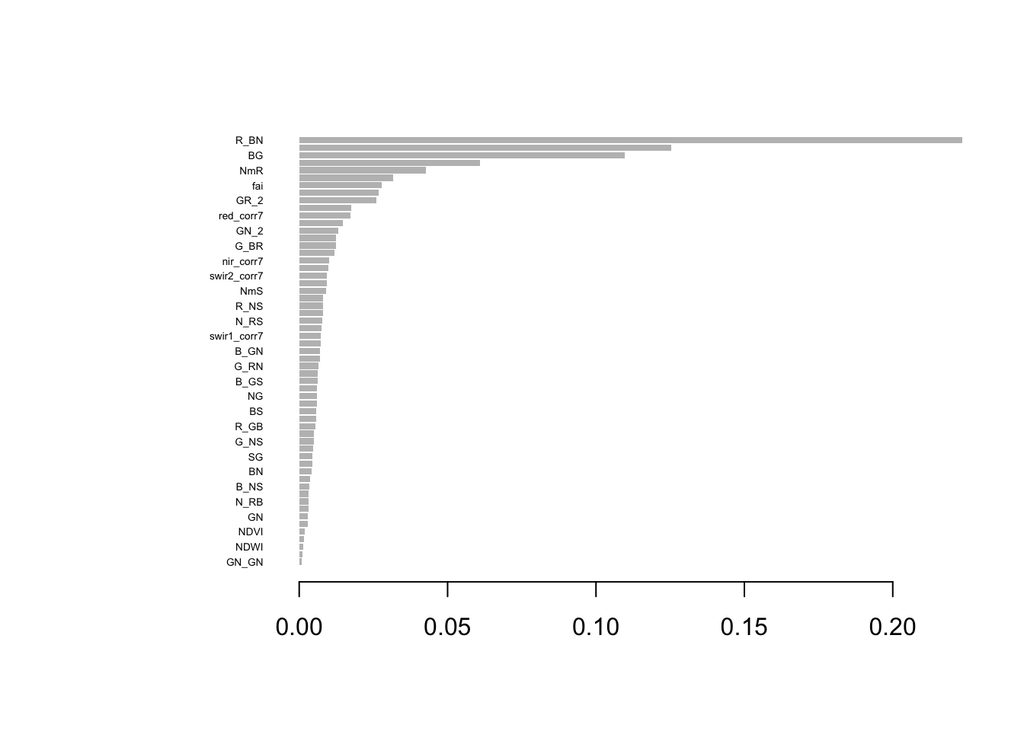

```r
importance <- xgb.importance(model = xgb.naive, feature_names = feats_candidate)
xgb.plot.importance(importance_matrix = importance)
```

```r
params_linear <- list(booster = "gblinear",
                      objective = 'reg:squarederror',
                      eta=0.1,
                      max_depth=7,
                      min_child_weight=1,
                      subsample=0.8,
                      colsample_bytree=0.5)

xgb.naive.2 <- xgb.train(params = params_linear,
                         data = dtrain1,
                         nrounds = 5000,
                         evals = list(train = dtrain1, val = dval1),
                         verbose = 1,
                         early_stopping_rounds = 100)
```

```
## Multiple eval metrics are present. Will use val_rmse for early stopping.
## Will train until val_rmse hasn't improved in 100 rounds.
##
## Stopping. Best iteration:
##
```

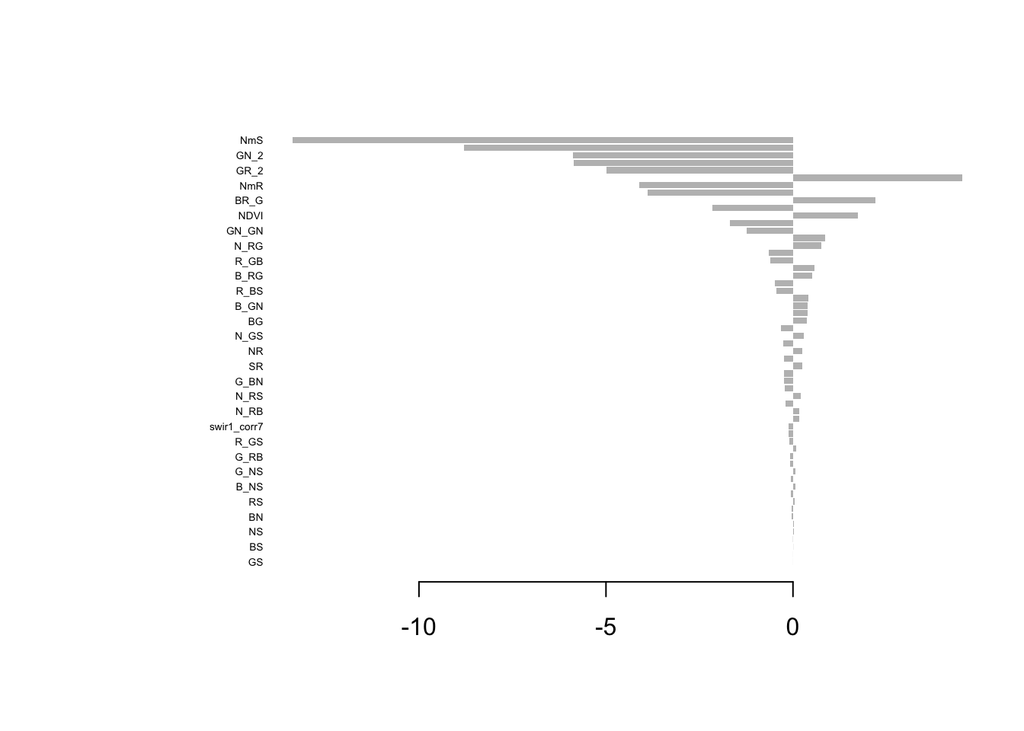

```r
importance.2 <- xgb.importance(model = xgb.naive.2, feature_names = feats_candidate)
xgb.plot.importance(importance_matrix = importance.2)
```

As expected, the linear tuner is much worse than the tree, so we’ll just stick with the tree version.

## Prune correlated features

```r
corr_threshold <- 0.95

cor_mat <- train_val %>%
  select(all_of(feats_candidate)) %>%
  as.matrix() %>%
  cor(use = "pairwise.complete.obs")

high_cor_idx <- which(abs(cor_mat) > corr_threshold & upper.tri(cor_mat), arr.ind = TRUE)

cor_edges <- tibble(from = rownames(cor_mat)[high_cor_idx[, 1]],
                    to = colnames(cor_mat)[high_cor_idx[, 2]])

cor_graph <- graph_from_data_frame(cor_edges, directed = FALSE, vertices = feats_candidate)
cor_clusters <- components(cor_graph)$membership

target_cor <- map_dbl(feats_candidate, ~ abs(cor(train_val[[.x]], train_val$harmonized_value,
                                                 use = "pairwise.complete.obs")))

cluster_tbl <- tibble(feature = names(cor_clusters),
                      cluster = cor_clusters,
                      target_cor = target_cor[names(cor_clusters)]) %>%
  arrange(cluster, desc(target_cor))

feats_decorr <- cluster_tbl %>%
  slice_max(target_cor, n = 1, by = cluster, with_ties = FALSE) %>%
  pull(feature)

# audit: which features got dropped, and in favor of which cluster-mate
cluster_tbl %>%
  mutate(kept = feature %in% feats_decorr) %>%
  filter(n() > 1, .by = cluster) %>%
  arrange(cluster, desc(kept))
```

```
## # A tibble: 32 × 4
##    feature     cluster target_cor kept
##    <chr>         <dbl>      <dbl> <lgl>
##  1 red_corr7         1         NA TRUE
##  2 green_corr7       1         NA FALSE
##  3 blue_corr7        1         NA FALSE
##  4 GR_2              1         NA FALSE
##  5 GN_2              1         NA FALSE
##  6 swir1_corr7       3         NA TRUE
##  7 swir2_corr7       3         NA FALSE
##  8 BR                5         NA TRUE
##  9 GR                5         NA FALSE
## 10 NG                9         NA TRUE
## # ℹ 22 more rows
```

Correlation pruning took the candidate set from 57 down to 37 features.

## Backward elimination with cross-fold consensus

We eliminate features one at a time using the same 4-fold leave-one-partition-out CV structure built above (`train1`/`val1` … `train4`/`val4`, i.e. partitions 1, 2, 3, and 5 — the test partition is still never touched). At each step we fit all 4 folds on the current feature set, decide which feature to drop next by averaging its importance (`Gain`) *across* the 4 folds rather than trusting any single fold, and record how many folds individually agree with that consensus pick, so disagreement between splits is visible rather than averaged away.

```r
elim_params <- list(booster = "gbtree",
                    objective = 'reg:squarederror',
                    eta = 0.05,
                    max_depth = 4,
                    min_child_weight = 3,
                    subsample = 0.8,
                    colsample_bytree = 0.8)

fit_fold <- function(train_df, val_df, feats, params, nrounds = 800, early_stopping_rounds = 25) {
  dtr <- xgb.DMatrix(data = as.matrix(train_df[, feats]), label = train_df$harmonized_value)
  dv  <- xgb.DMatrix(data = as.matrix(val_df[, feats]), label = val_df$harmonized_value)

  fit <- xgb.train(params = params, data = dtr, nrounds = nrounds,
                   evals = list(train = dtr, val = dv),
                   verbose = 0,
                   early_stopping_rounds = early_stopping_rounds)

  list(rmse = unname(attr(fit, "early_stop")$best_score),
       importance = xgb.importance(model = fit, feature_names = feats))
}

elim_folds <- list(list(train = train1, val = val1),
                   list(train = train2, val = val2),
                   list(train = train3, val = val3),
                   list(train = train4, val = val4))
```

```r
set.seed(47)

min_feats <- 3
current_feats <- feats_decorr
history <- list()
step <- 1

repeat {
  fold_fits <- map(elim_folds, ~ fit_fold(.x$train, .x$val, current_feats, elim_params))
  fold_rmse <- map_dbl(fold_fits, "rmse")

  imp_long <- map2_dfr(fold_fits, seq_along(fold_fits),
                       ~ mutate(.x$importance, fold = .y)) %>%
    select(Feature, fold, Gain) %>%
    complete(Feature = current_feats, fold = seq_along(elim_folds), fill = list(Gain = 0)) %>%
    mutate(rank = rank(Gain), .by = fold)

  consensus <- imp_long %>%
    summarise(mean_gain = mean(Gain), .by = Feature) %>%
    arrange(mean_gain)

  drop_feat <- consensus$Feature[1]
  concordance <- imp_long %>%
    filter(Feature == drop_feat, rank <= 3) %>%
    nrow()

  history[[step]] <- tibble(step = step,
                            n_features = length(current_feats),
                            mean_rmse = mean(fold_rmse),
                            se_rmse = sd(fold_rmse) / sqrt(length(fold_rmse)),
                            dropped_feature = drop_feat,
                            concordance = concordance,
                            fold_rmse = list(fold_rmse),
                            retained_features = list(current_feats),
                            fold_importance = list(imp_long))

  if (length(current_feats) <= min_feats) break

  current_feats <- setdiff(current_feats, drop_feat)
  step <- step + 1
}

elim_history <- bind_rows(history)
```

Plot the elimination curve (mean validation RMSE across the 4 folds, ± 1 SE, as features are removed).

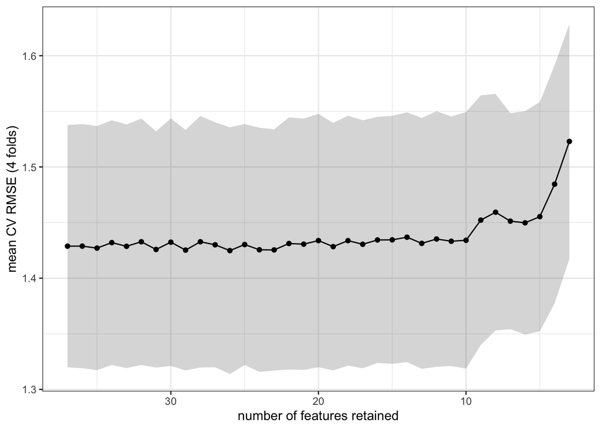

```r
ggplot(elim_history, aes(x = n_features, y = mean_rmse)) +
  geom_ribbon(aes(ymin = mean_rmse - se_rmse, ymax = mean_rmse + se_rmse), alpha = 0.2) +
  geom_line() +
  geom_point() +
  scale_x_reverse() +
  labs(x = "number of features retained",
       y = "mean CV RMSE (4 folds)") +
  theme_bw()
```

An automatic rule (e.g. 1-SE off the minimum) is too easily fooled here: with only 4 folds, `se_rmse` is a noisy estimate and can be wide enough to make a real, visible rise in RMSE look like statistical noise, pulling the “optimal” count all the way down to `min_feats`. Instead, read the elimination curve above and set `n_features_selected` to the point where mean CV RMSE starts climbing (the visible knee), then check how much the 4 folds agree at that step — both on overall performance (fold RMSE spread) and on which retained features actually matter to each fold individually (Gain by fold).

```r
# set this by eye from the elimination-plot above: the number of features
# right before mean CV RMSE starts climbing
n_features_selected <- 10

stopifnot("n_features_selected must match a step in elim_history" =
            n_features_selected %in% elim_history$n_features)

selected_row <- elim_history %>%
  filter(n_features == n_features_selected)

feats_selected <- selected_row$retained_features[[1]]

# persist for reuse by 05_split_seed_sensitivity.Rmd, so that script doesn't
# need to re-run (eyeballed) elimination to get the same feature set
write_rds(feats_selected, "regional_clarity/xg_models/prelim/feats_selected.rds")

# fold RMSE spread at the selected step
tibble(fold = seq_along(selected_row$fold_rmse[[1]]),
       rmse = selected_row$fold_rmse[[1]])
```

```
## # A tibble: 4 × 2
##    fold  rmse
##   <int> <dbl>
## 1     1  1.21
## 2     2  1.28
## 3     3  1.70
## 4     4  1.54
```

```r
# per-fold Gain for each retained feature at the selected step
selected_row$fold_importance[[1]] %>%
  select(Feature, fold, Gain) %>%
  pivot_wider(names_from = fold, names_prefix = "fold", values_from = Gain) %>%
  arrange(desc(rowSums(across(starts_with("fold")))))
```

```
## # A tibble: 10 × 5
##    Feature         fold1  fold2  fold3  fold4
##    <chr>           <dbl>  <dbl>  <dbl>  <dbl>
##  1 R_BN           0.393  0.455  0.394  0.492
##  2 R_BS           0.0604 0.131  0.156  0.153
##  3 BG             0.130  0.0901 0.0886 0.0671
##  4 red_corr7      0.0825 0.0740 0.106  0.0680
##  5 fai            0.0725 0.0565 0.0818 0.0584
##  6 B_RG           0.136  0.0633 0.0377 0.0297
##  7 G_BN           0.0630 0.0570 0.0352 0.0522
##  8 G_BR           0.0218 0.0306 0.0532 0.0352
##  9 NmS            0.0239 0.0208 0.0271 0.0222
## 10 atm_corr_LaSRC 0.0179 0.0220 0.0207 0.0223
```

Backward elimination selected 10 features (from 37 after correlation pruning, 57 originally).

Rebuild the fold DMatrices and the held-out test DMatrix using the selected feature set — everything downstream (hyperparameter tuning, final training, test evaluation) now runs on `feats_selected`.

```r
feats <- feats_selected

dtrain1 <- xgb.DMatrix(data = as.matrix(train1[,feats]),
                       label = train1$harmonized_value)
dval1 <- xgb.DMatrix(data = as.matrix(val1[,feats]),
                     label = val1$harmonized_value)

dtrain2 <- xgb.DMatrix(data = as.matrix(train2[,feats]),
                       label = train2$harmonized_value)
dval2 <- xgb.DMatrix(data = as.matrix(val2[,feats]),
                     label = val2$harmonized_value)

dtrain3 <- xgb.DMatrix(data = as.matrix(train3[,feats]),
                       label = train3$harmonized_value)
dval3 <- xgb.DMatrix(data = as.matrix(val3[,feats]),
                     label = val3$harmonized_value)

dtrain4 <- xgb.DMatrix(data = as.matrix(train4[,feats]),
                       label = train4$harmonized_value)
dval4 <- xgb.DMatrix(data = as.matrix(val4[,feats]),
                     label = val4$harmonized_value)

dtest <- xgb.DMatrix(data = as.matrix(test[,feats]),
                     label = test$harmonized_value)
```

## Hyperparameter tuning

We grid search `max_depth` and `min_child_weight` for the `gbtree` booster in two rounds. Each grid point is fit across all 4 CV folds (not just fold 1) so the score reflects how well a parameter combination generalizes across partitions rather than how well it happens to fit one — same cross-fold logic as the feature elimination step above, and still only ever touching `dtrain1..4`/`dval1..4` (partitions 1, 2, 3, 5), never the held-out test partition. Alongside `mean_val_loss`, each grid point also reports `mean_train_loss` and `mean_gap` (mean val − train RMSE across folds, at the same early-stopped iteration used for `mean_val_loss`) — useful for spotting combinations that look good on validation loss alone but are already overfitting relative to their own training data.

```r
tune_folds <- list(list(train = dtrain1, val = dval1),
                   list(train = dtrain2, val = dval2),
                   list(train = dtrain3, val = dval3),
                   list(train = dtrain4, val = dval4))

hypertune_xgboost = function(folds, grid){

  params <- list(booster = "gbtree",
                 objective = 'reg:squarederror',
                 eta=grid$eta,
                 max_depth=grid$max_depth,
                 min_child_weight=grid$min_child_weight,
                 subsample=grid$subsample,
                 colsample_bytree=grid$colsample_bytree)

  fold_results <- map(folds, function(fold) {
    xgb <- xgb.train(params = params, data = fold$train, nrounds = 5000,
                     evals = list(train = fold$train, val = fold$val),
                     verbose = 0,
                     early_stopping_rounds = 100)

    # as of xgboost >=2.0, fit results (best_score, best_iteration) live in
    # attributes rather than list elements, so xgb$best_score no longer works
    early_stop <- attr(xgb, "early_stop")

    # train RMSE at that same (early-stopped) iteration, so the train/val gap
    # reflects the model actually being scored rather than wherever training
    # happened to stop logging; as of xgboost >=2.0, evaluation_log also
    # lives in an attribute rather than a list element
    train_loss <- attr(xgb, "evaluation_log") %>%
      filter(iter == early_stop$best_iteration) %>%
      pull(train_rmse)

    list(val_loss = unname(early_stop$best_score),
         train_loss = train_loss,
         best_iteration = early_stop$best_iteration)
  })

  val_losses <- map_dbl(fold_results, "val_loss")
  train_losses <- map_dbl(fold_results, "train_loss")
  gaps <- val_losses - train_losses

  summary <- grid %>% mutate(mean_val_loss = mean(val_losses),
                             se_val_loss = sd(val_losses) / sqrt(length(val_losses)),
                             mean_train_loss = mean(train_losses),
                             # val - train: how much worse a combo does on
                             # held-out data than on the data it was fit to;
                             # a bigger gap is a sign of overfitting even if
                             # mean_val_loss itself looks competitive
                             mean_gap = mean(gaps),
                             se_gap = sd(gaps) / sqrt(length(gaps)),
                             fold_val_loss = list(val_losses),
                             fold_train_loss = list(train_losses),
                             mean_best_iteration = mean(map_dbl(fold_results, "best_iteration")))

  return(summary)

}
```

Round 1: a broad grid over `max_depth`, `min_child_weight`, `eta`, and `colsample_bytree`. `max_depth`’s upper range is narrower than a first pass would use on the full ~50-feature candidate set, since with only a handful of features surviving pruning/elimination, deep trees (7+) mostly just cost runtime rather than add anything. `eta` and `colsample_bytree` are searched here rather than fixed, since the final training run uses a much lower `eta` than earlier drafts assumed, and `colsample_bytree` was tuned back when there were far more (collinear) candidate features than there are now — both are worth re-checking against the current, pruned feature set rather than carrying old defaults forward. This grid is 5 × 4 × 3 × 3 = 180 combinations × 4 folds = 720 fits.

```r
param_test1 <- expand.grid(
  booster = "gbtree",
  objective = 'reg:squarederror',
  eta = c(0.01, 0.05, 0.1),
  max_depth = c(2, 3, 4, 5, 6),
  min_child_weight = c(1, 3, 5, 7),
  subsample = 0.8,
  colsample_bytree = c(0.5, 0.7, 1)
) %>%
  rowid_to_column()

## Hypertune xgboost for max depth, child weight, eta, and colsample_bytree
xgboost_hypertune <- param_test1 %>%
  pmap_dfr(function(...) {
    current <- tibble(...)
    hypertune_xgboost(tune_folds, current)
  })

xgboost_hypertune %>%
  arrange(mean_val_loss) %>%
  select(-c(fold_val_loss, fold_train_loss))
```

```
## # A tibble: 180 × 14
##    rowid booster objective          eta max_depth min_child_weight subsample
##    <int> <fct>   <fct>            <dbl>     <dbl>            <dbl>     <dbl>
##  1    29 gbtree  reg:squarederror  0.05         6                3       0.8
##  2     8 gbtree  reg:squarederror  0.05         4                1       0.8
##  3    11 gbtree  reg:squarederror  0.05         5                1       0.8
##  4    52 gbtree  reg:squarederror  0.01         4                7       0.8
##  5    10 gbtree  reg:squarederror  0.01         5                1       0.8
##  6    51 gbtree  reg:squarederror  0.1          3                7       0.8
##  7    68 gbtree  reg:squarederror  0.05         4                1       0.8
##  8    20 gbtree  reg:squarederror  0.05         3                3       0.8
##  9    35 gbtree  reg:squarederror  0.05         3                5       0.8
## 10    41 gbtree  reg:squarederror  0.05         5                5       0.8
## # ℹ 170 more rows
## # ℹ 7 more variables: colsample_bytree <dbl>, mean_val_loss <dbl>,
## #   se_val_loss <dbl>, mean_train_loss <dbl>, mean_gap <dbl>, se_gap <dbl>,
## #   mean_best_iteration <dbl>
```

Round 2: refine around round 1’s best combination. `eta` is locked to round 1’s winning value (its 3-point grid was only meant to find the right ballpark, not to be refined further), while `max_depth`, `min_child_weight`, and `colsample_bytree` get a tight neighborhood search — built programmatically off round 1’s actual winner rather than re-typed by hand, so this stays correct if the upstream feature set (and therefore round 1’s result) changes on a rerun.

```r
round1_best <- xgboost_hypertune %>%
  slice_min(mean_val_loss, n = 1, with_ties = FALSE)

param_test2 <- expand.grid(
  booster = "gbtree",
  objective = 'reg:squarederror',
  eta = round1_best$eta,
  max_depth = unique(pmax(2, round1_best$max_depth + c(-1, 0, 1))),
  min_child_weight = unique(pmax(1, round1_best$min_child_weight + c(-2, 0, 2))),
  subsample = 0.8,
  colsample_bytree = unique(pmin(1, pmax(0.3, round1_best$colsample_bytree + c(-0.15, 0, 0.15))))
) %>%
  rowid_to_column()

xgboost_hypertune2 <- param_test2 %>%
  pmap_dfr(function(...) {
    current <- tibble(...)
    hypertune_xgboost(tune_folds, current)
  })

xgboost_hypertune2 %>%
  arrange(mean_val_loss) %>%
  select(-c(fold_val_loss, fold_train_loss))
```

```
## # A tibble: 27 × 14
##    rowid booster objective          eta max_depth min_child_weight subsample
##    <int> <fct>   <fct>            <dbl>     <dbl>            <dbl>     <dbl>
##  1     4 gbtree  reg:squarederror  0.05         5                3       0.8
##  2     8 gbtree  reg:squarederror  0.05         6                5       0.8
##  3     1 gbtree  reg:squarederror  0.05         5                1       0.8
##  4     2 gbtree  reg:squarederror  0.05         6                1       0.8
##  5     6 gbtree  reg:squarederror  0.05         7                3       0.8
##  6    19 gbtree  reg:squarederror  0.05         5                1       0.8
##  7    10 gbtree  reg:squarederror  0.05         5                1       0.8
##  8    14 gbtree  reg:squarederror  0.05         6                3       0.8
##  9    16 gbtree  reg:squarederror  0.05         5                5       0.8
## 10     7 gbtree  reg:squarederror  0.05         5                5       0.8
## # ℹ 17 more rows
## # ℹ 7 more variables: colsample_bytree <dbl>, mean_val_loss <dbl>,
## #   se_val_loss <dbl>, mean_train_loss <dbl>, mean_gap <dbl>, se_gap <dbl>,
## #   mean_best_iteration <dbl>
```

## Train and cross-validate final models

We take round 2’s winning combination directly rather than hand-copying numbers in, so this stays correct if the tuning grid or upstream feature set changes on a rerun. The pick below is just the lowest `mean_val_loss`; `mean_gap` (mean val − train RMSE across folds) is included alongside it so you can sanity-check overfitting risk before trusting that pick — if a combination just behind it on `mean_val_loss` has a noticeably smaller `mean_gap`, override `final_hyperparams` below with that row’s `rowid` instead.

```r
final_hyperparams <- xgboost_hypertune2 %>%
  slice_min(mean_val_loss, n = 1, with_ties = FALSE)

# to override with a different row after weighing mean_gap against
# mean_val_loss in the table above, e.g.:
# final_hyperparams <- xgboost_hypertune2 %>% filter(rowid == <id>)

# persist for reuse by 05_split_seed_sensitivity.Rmd, so that script doesn't
# need to re-run hyperparameter tuning to get the same configuration
write_rds(final_hyperparams, "regional_clarity/xg_models/prelim/final_hyperparams.rds")

final_hyperparams %>%
  select(-c(fold_val_loss, fold_train_loss))
```

```
## # A tibble: 1 × 14
##   rowid booster objective          eta max_depth min_child_weight subsample
##   <int> <fct>   <fct>            <dbl>     <dbl>            <dbl>     <dbl>
## 1     4 gbtree  reg:squarederror  0.05         5                3       0.8
## # ℹ 7 more variables: colsample_bytree <dbl>, mean_val_loss <dbl>,
## #   se_val_loss <dbl>, mean_train_loss <dbl>, mean_gap <dbl>, se_gap <dbl>,
## #   mean_best_iteration <dbl>
```

```r
params <- list(booster = "gbtree",
               objective = 'reg:squarederror',
               eta = final_hyperparams$eta,
               max_depth = final_hyperparams$max_depth,
               min_child_weight = final_hyperparams$min_child_weight,
               subsample = final_hyperparams$subsample,
               colsample_bytree = final_hyperparams$colsample_bytree)

set.seed(47)
xgb1 <- xgb.train(params = params, data = dtrain1, nrounds = 5000,
                  evals = list(train = dtrain1, val = dval1),
                  verbose = 1,
                  early_stopping_rounds = 250)
```

```
## Multiple eval metrics are present. Will use val_rmse for early stopping.
## Will train until val_rmse hasn't improved in 250 rounds.
##
## Stopping. Best iteration:
##
```

```r
xgb.save(xgb1, "regional_clarity/xg_models/prelim/xgb1.model")
```

```
## [1] TRUE
```

```r
xgb2 <- xgb.train(params = params, data = dtrain2, nrounds = 5000,
                  evals = list(train = dtrain2, val = dval2),
                  verbose = 1,
                  early_stopping_rounds = 250)
```

```
## Multiple eval metrics are present. Will use val_rmse for early stopping.
## Will train until val_rmse hasn't improved in 250 rounds.
##
## Stopping. Best iteration:
##
```

```r
xgb.save(xgb2, "regional_clarity/xg_models/prelim/xgb2.model")
```

```
## [1] TRUE
```

```r
xgb3 <- xgb.train(params = params, data = dtrain3, nrounds = 5000,
                  evals = list(train = dtrain3, val = dval3),
                  verbose = 1,
                  early_stopping_rounds = 250)
```

```
## Multiple eval metrics are present. Will use val_rmse for early stopping.
## Will train until val_rmse hasn't improved in 250 rounds.
##
## Stopping. Best iteration:
##
```

```r
xgb.save(xgb3, "regional_clarity/xg_models/prelim/xgb3.model")
```

```
## [1] TRUE
```

```r
xgb4 <- xgb.train(params = params, data = dtrain4, nrounds = 5000,
                  evals = list(train = dtrain4, val = dval4),
                  verbose = 1,
                  early_stopping_rounds = 250)
```

```
## Multiple eval metrics are present. Will use val_rmse for early stopping.
## Will train until val_rmse hasn't improved in 250 rounds.
##
## Stopping. Best iteration:
##
```

```r
xgb.save(xgb4, "regional_clarity/xg_models/prelim/xgb4.model")
```

```
## [1] TRUE
```

For each fold, average the predictions from all four models and compare against the fold’s own held-out validation set.

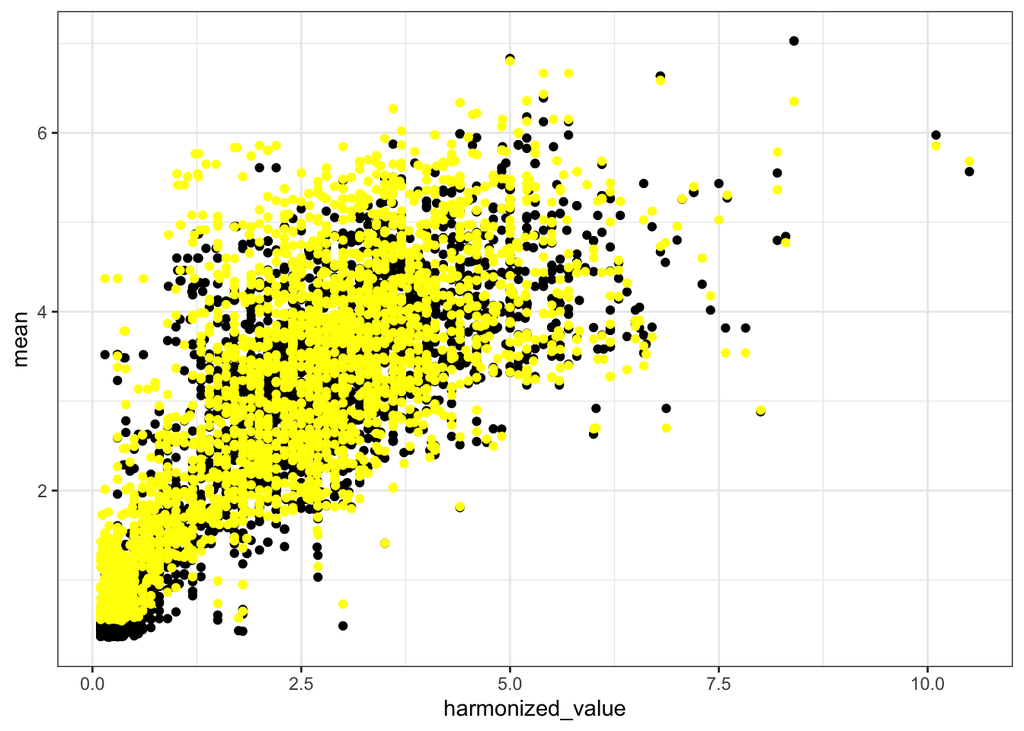

```r
pred_1 <- val1 %>%
  mutate(pred1 = predict(xgb1, dval1),
         pred2 = predict(xgb2, dval1),
         pred3 = predict(xgb3, dval1),
         pred4 = predict(xgb4, dval1)) %>%
  rowwise() %>%
  mutate(mean = sum(pred1, pred2, pred3, pred4)/4)

ggplot(pred_1, aes(x = harmonized_value, y = mean)) +
  geom_point() +
  geom_point(aes(y = pred1), color = "yellow") +
  theme_bw()
```

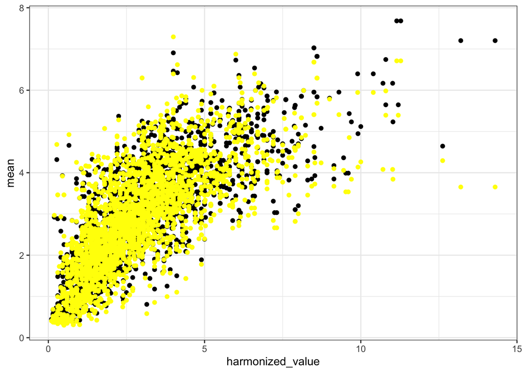

```r
pred_2 <- val2 %>%
  mutate(pred1 = predict(xgb1, dval2),
         pred2 = predict(xgb2, dval2),
         pred3 = predict(xgb3, dval2),
         pred4 = predict(xgb4, dval2)) %>%
  rowwise() %>%
  mutate(mean = sum(pred1, pred2, pred3, pred4)/4)

ggplot(pred_2, aes(x = harmonized_value, y = mean)) +
  geom_point() +
  geom_point(aes(y = pred2), color = "yellow") +
  theme_bw()
```

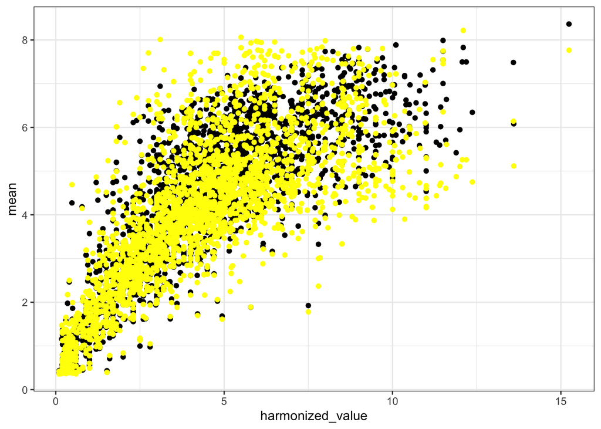

```r
pred_3 <- val3 %>%
  mutate(pred1 = predict(xgb1, dval3),
         pred2 = predict(xgb2, dval3),
         pred3 = predict(xgb3, dval3),
         pred4 = predict(xgb4, dval3)) %>%
  rowwise() %>%
  mutate(mean = sum(pred1, pred2, pred3, pred4)/4)

ggplot(pred_3, aes(x = harmonized_value, y = mean)) +
  geom_point() +
  geom_point(aes(y = pred3), color = "yellow") +
  theme_bw()
```

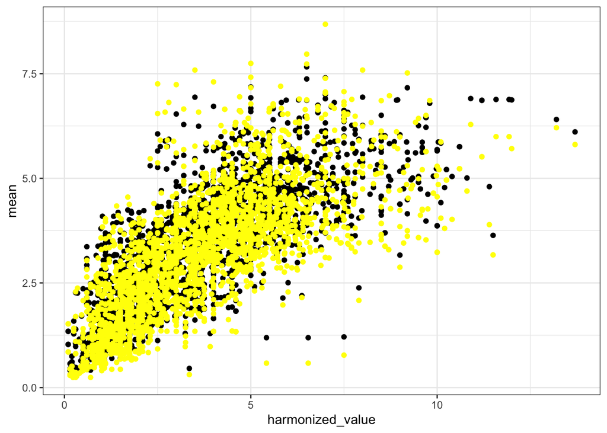

```r
pred_4 <- val4 %>%
  mutate(pred1 = predict(xgb1, dval4),
         pred2 = predict(xgb2, dval4),
         pred3 = predict(xgb3, dval4),
         pred4 = predict(xgb4, dval4)) %>%
  rowwise() %>%
  mutate(mean = sum(pred1, pred2, pred3, pred4)/4)

ggplot(pred_4, aes(x = harmonized_value, y = mean)) +
  geom_point() +
  geom_point(aes(y = pred4), color = "yellow") +
  theme_bw()
```

## Re-weight training toward high-SDD values

Across all four folds above, predictions increasingly fall below the 1:1 line as observed SDD grows — a “ceiling” effect that’s common when a squared-error loss is fit to a right-skewed target: the dense cluster of low/mid-SDD observations dominates the loss, so the model is never pushed hard to get the sparse high-SDD tail right. Here we refit each fold with per-observation training weights that scale linearly with SDD, so a high-SDD point counts for more during training, likely at a small cost to overall (low/mid-range) accuracy. This is a comparison, not a replacement: the unweighted `xgb1`-`xgb4` above are left untouched and still carry through to the held-out test evaluation below; the weighted models here are a parallel set (`xgb1_w`-`xgb4_w`).

```r
# weight strength: at weight_strength = k, the highest-SDD training
# observation in a fold is weighted (1 + k) times as heavily as the lowest;
# tune by eye against the comparison metrics/plot below - start modest
# since this trades off overall accuracy for high-SDD accuracy
weight_strength <- 2

sdd_weight <- function(value, k = weight_strength) {
  rng <- range(value, na.rm = TRUE)
  1 + k * (value - rng[1]) / (rng[2] - rng[1])
}
```

Build training DMatrices with these weights attached. Validation DMatrices stay the existing unweighted `dval1..4`, so early stopping and the reported val-rmse remain directly comparable to the unweighted models above.

```r
dtrain1_w <- xgb.DMatrix(data = as.matrix(train1[,feats]),
                         label = train1$harmonized_value,
                         weight = sdd_weight(train1$harmonized_value))
dtrain2_w <- xgb.DMatrix(data = as.matrix(train2[,feats]),
                         label = train2$harmonized_value,
                         weight = sdd_weight(train2$harmonized_value))
dtrain3_w <- xgb.DMatrix(data = as.matrix(train3[,feats]),
                         label = train3$harmonized_value,
                         weight = sdd_weight(train3$harmonized_value))
dtrain4_w <- xgb.DMatrix(data = as.matrix(train4[,feats]),
                         label = train4$harmonized_value,
                         weight = sdd_weight(train4$harmonized_value))
```

Retrain each fold using the same tuned hyperparameters and early-stopping settings as the unweighted final models above, changing only the training data to add weights.

```r
xgb1_w <- xgb.train(params = params, data = dtrain1_w, nrounds = 5000,
                    evals = list(train = dtrain1_w, val = dval1),
                    verbose = 1,
                    early_stopping_rounds = 250)
```

```
## Multiple eval metrics are present. Will use val_rmse for early stopping.
## Will train until val_rmse hasn't improved in 250 rounds.
##
## Stopping. Best iteration:
##
```

```r
xgb.save(xgb1_w, "regional_clarity/xg_models/prelim/xgb1_weighted.model")
```

```
## [1] TRUE
```

```r
xgb2_w <- xgb.train(params = params, data = dtrain2_w, nrounds = 5000,
                    evals = list(train = dtrain2_w, val = dval2),
                    verbose = 1,
                    early_stopping_rounds = 250)
```

```
## Multiple eval metrics are present. Will use val_rmse for early stopping.
## Will train until val_rmse hasn't improved in 250 rounds.
##
## Stopping. Best iteration:
##
```

```r
xgb.save(xgb2_w, "regional_clarity/xg_models/prelim/xgb2_weighted.model")
```

```
## [1] TRUE
```

```r
xgb3_w <- xgb.train(params = params, data = dtrain3_w, nrounds = 5000,
                    evals = list(train = dtrain3_w, val = dval3),
                    verbose = 1,
                    early_stopping_rounds = 250)
```

```
## Multiple eval metrics are present. Will use val_rmse for early stopping.
## Will train until val_rmse hasn't improved in 250 rounds.
##
## Stopping. Best iteration:
##
```

```r
xgb.save(xgb3_w, "regional_clarity/xg_models/prelim/xgb3_weighted.model")
```

```
## [1] TRUE
```

```r
xgb4_w <- xgb.train(params = params, data = dtrain4_w, nrounds = 5000,
                    evals = list(train = dtrain4_w, val = dval4),
                    verbose = 1,
                    early_stopping_rounds = 250)
```

```
## Multiple eval metrics are present. Will use val_rmse for early stopping.
## Will train until val_rmse hasn't improved in 250 rounds.
##
## Stopping. Best iteration:
##
```

```r
xgb.save(xgb4_w, "regional_clarity/xg_models/prelim/xgb4_weighted.model")
```

```
## [1] TRUE
```

Add the weighted ensemble’s predictions onto the existing fold prediction tibbles, so both models’ predictions live on the same rows for direct comparison.

```r
pred_1 <- pred_1 %>%
  ungroup() %>%
  mutate(w_pred1 = predict(xgb1_w, dval1),
         w_pred2 = predict(xgb2_w, dval1),
         w_pred3 = predict(xgb3_w, dval1),
         w_pred4 = predict(xgb4_w, dval1),
         mean_w = (w_pred1 + w_pred2 + w_pred3 + w_pred4)/4)

pred_2 <- pred_2 %>%
  ungroup() %>%
  mutate(w_pred1 = predict(xgb1_w, dval2),
         w_pred2 = predict(xgb2_w, dval2),
         w_pred3 = predict(xgb3_w, dval2),
         w_pred4 = predict(xgb4_w, dval2),
         mean_w = (w_pred1 + w_pred2 + w_pred3 + w_pred4)/4)

pred_3 <- pred_3 %>%
  ungroup() %>%
  mutate(w_pred1 = predict(xgb1_w, dval3),
         w_pred2 = predict(xgb2_w, dval3),
         w_pred3 = predict(xgb3_w, dval3),
         w_pred4 = predict(xgb4_w, dval3),
         mean_w = (w_pred1 + w_pred2 + w_pred3 + w_pred4)/4)

pred_4 <- pred_4 %>%
  ungroup() %>%
  mutate(w_pred1 = predict(xgb1_w, dval4),
         w_pred2 = predict(xgb2_w, dval4),
         w_pred3 = predict(xgb3_w, dval4),
         w_pred4 = predict(xgb4_w, dval4),
         mean_w = (w_pred1 + w_pred2 + w_pred3 + w_pred4)/4)
```

Compare unweighted vs. weighted RMSE, split into the top quartile of SDD (by `train_val`’s own distribution, never touching the test partition) vs. the rest, to see whether the trade actually paid off and how much it cost.

```r
top_quartile_cut <- quantile(train_val$harmonized_value, 0.75, na.rm = TRUE)

compare_tbl <- bind_rows(pred_1 %>% mutate(fold = 1),
                         pred_2 %>% mutate(fold = 2),
                         pred_3 %>% mutate(fold = 3),
                         pred_4 %>% mutate(fold = 4)) %>%
  ungroup() %>%
  mutate(sdd_group = if_else(harmonized_value >= top_quartile_cut,
                             "top quartile", "rest"))

compare_tbl %>%
  summarise(rmse_unweighted = rmse(harmonized_value, mean),
            rmse_weighted = rmse(harmonized_value, mean_w),
            n = n(),
            .by = sdd_group)
```

```
## # A tibble: 2 × 4
##   sdd_group    rmse_unweighted rmse_weighted     n
##   <chr>                  <dbl>         <dbl> <int>
## 1 rest                   0.913         0.977  8831
## 2 top quartile           1.86          1.62   3070
```

Plot predicted vs. observed SDD for both models across all four validation folds, to visually check whether the high tail moved closer to the 1:1 line.

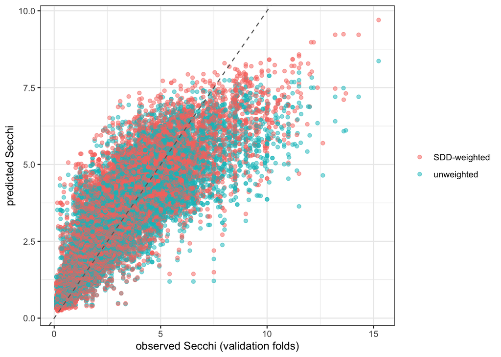

```r
compare_tbl %>%
  pivot_longer(c(mean, mean_w), names_to = "model", values_to = "prediction") %>%
  mutate(model = if_else(model == "mean", "unweighted", "SDD-weighted")) %>%
  ggplot(aes(x = harmonized_value, y = prediction, color = model)) +
  geom_point(alpha = 0.5) +
  geom_abline(slope = 1, intercept = 0, lty = 2, col = "grey40") +
  labs(x = "observed Secchi (validation folds)",
       y = "predicted Secchi",
       color = NULL) +
  theme_bw()
```

## Apply to held-out test partition

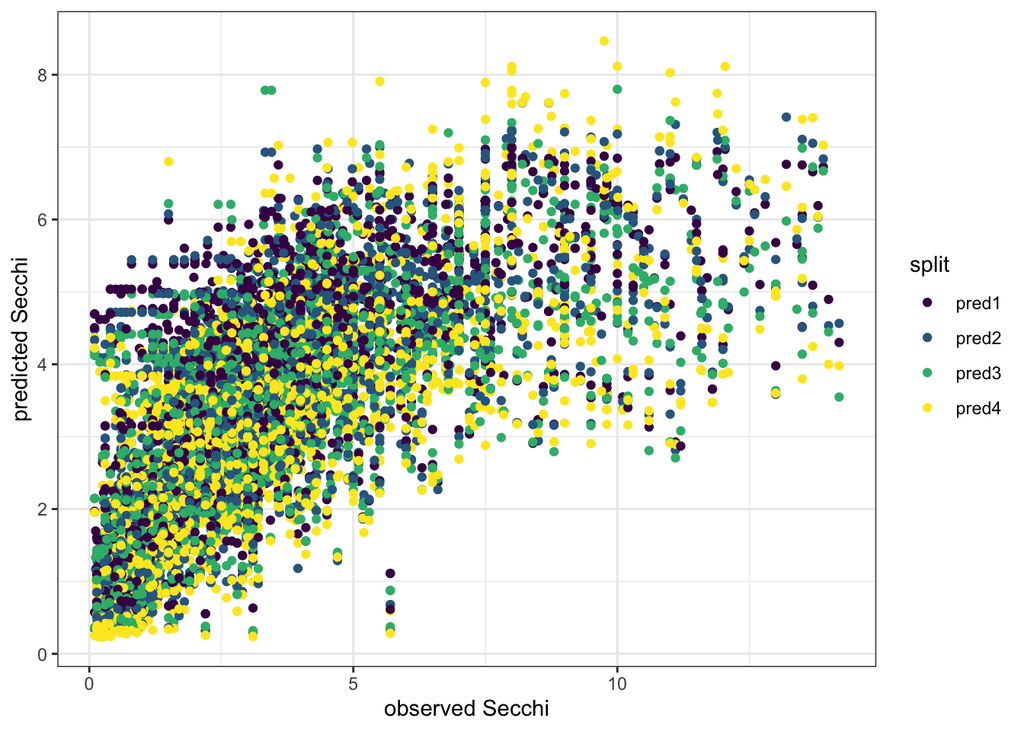

```r
test_pred <- test %>%
  mutate(pred1 = predict(xgb1, dtest),
         pred2 = predict(xgb2, dtest),
         pred3 = predict(xgb3, dtest),
         pred4 = predict(xgb4, dtest)) %>%
  rowwise() %>%
  mutate(mean = sum(pred1, pred2, pred3, pred4)/4) %>%
  filter(misc_flag != 1)

test_vert <- test_pred %>%
  pivot_longer(pred1:pred4,
               names_to = "pred",
               values_to = "values")

ggplot(test_vert, aes(x = harmonized_value, y = values)) +
  geom_point(aes(color = pred)) +
  scale_color_viridis_d() +
  labs(x = "observed Secchi",
       y = "predicted Secchi",
       color = "split") +
  theme_bw()
```

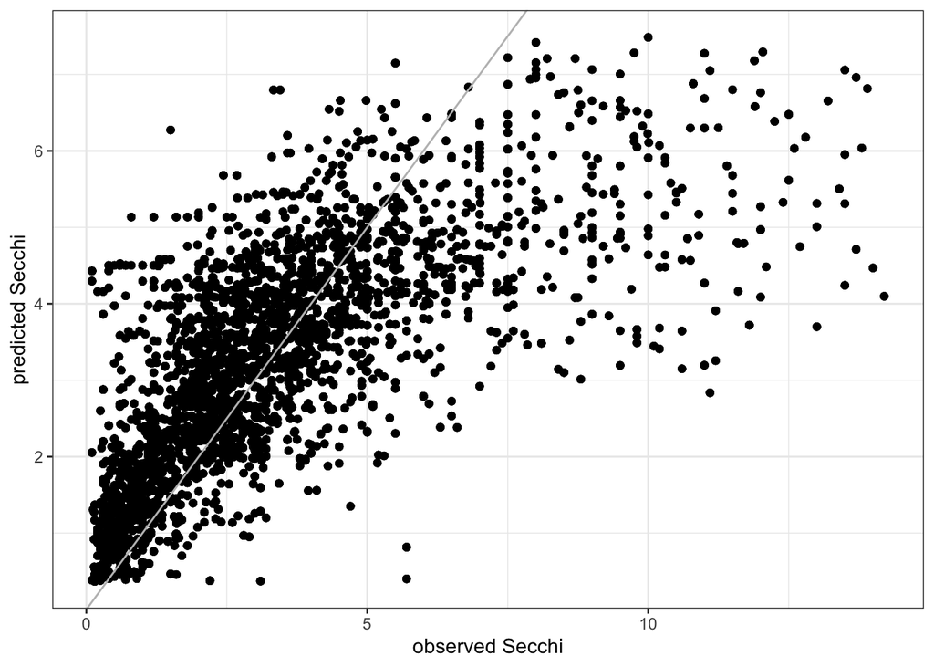

```r
ggplot(test_vert, aes(x = harmonized_value, y = mean)) +
  geom_point() +
  labs(x = "observed Secchi",
       y = "predicted Secchi") +
  geom_abline(slope = 1, intercept = 0, lty = 1, col = "grey") +
  theme_bw()
```

Summarize test-set error with standard regression metrics.

```r
evals_test <- test_pred %>%
  ungroup() %>%
  summarise(rmse = rmse(harmonized_value, mean),
            mae = mae(harmonized_value, mean),
            mape = mape(harmonized_value, mean),
            bias = bias(harmonized_value, mean),
            p.bias = percent_bias(harmonized_value, mean),
            smape = smape(harmonized_value, mean),
            r2 = cor(harmonized_value, mean)^2)
evals_test
```

```
## # A tibble: 1 × 7
##    rmse   mae  mape   bias p.bias smape    r2
##   <dbl> <dbl> <dbl>  <dbl>  <dbl> <dbl> <dbl>
## 1  1.84  1.25 0.688 0.0905 -0.475 0.415 0.512
```

Look at some longer test-set records over time, and their residuals, as a sanity check.

```r
test_long <- test_pred %>%
  ungroup() %>%
  summarize(n = n(), .by = siteSR_id) %>%
  filter(n > 50) %>%
  left_join(., test_pred)
```

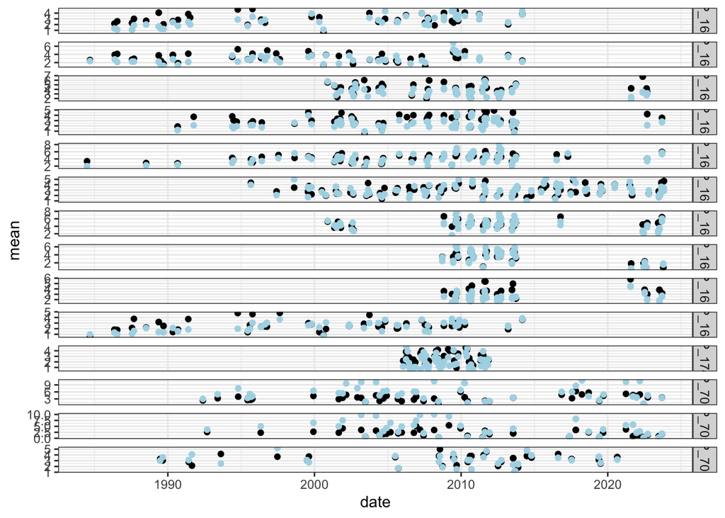

```r
ggplot(test_long, aes(x = date, y = mean)) +
  geom_point() +
  geom_point(aes(y = harmonized_value), color = "light blue") +
  facet_grid(siteSR_id ~ ., scales = "free_y") +
  theme_bw()
```

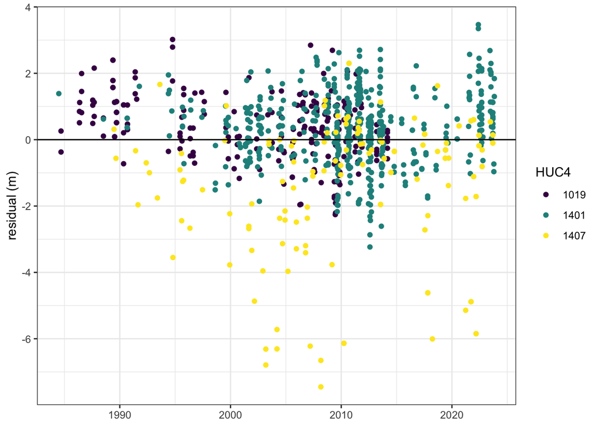

```r
ggplot(test_long, aes(x = date, y = mean - harmonized_value, color = HUC4)) +
  geom_point() +
  labs(y = "residual (m)",
       x = NULL) +
  theme_bw() +
  scale_color_viridis_d() +
  geom_abline(slope = 0, intercept = 0)
```

## Performance by HUC4

The residual plot above suggests error isn’t uniform across HUC4 basins. Break out the same test-set metrics computed above (`evals_test`), by HUC4, across all held-out test observations (not just the longer-record subset used for the time-series plot above), to see which basins the model generalizes to well and which it doesn’t.

```r
evals_test_huc4 <- test_pred %>%
  ungroup() %>%
  summarise(n = n(),
            rmse = rmse(harmonized_value, mean),
            mae = mae(harmonized_value, mean),
            mape = mape(harmonized_value, mean),
            bias = bias(harmonized_value, mean),
            p.bias = percent_bias(harmonized_value, mean),
            smape = smape(harmonized_value, mean),
            r2 = cor(harmonized_value, mean)^2,
            .by = HUC4) %>%
  arrange(desc(rmse))

evals_test_huc4
```

```
## # A tibble: 8 × 9
##   HUC4      n  rmse   mae  mape   bias  p.bias smape    r2
##   <chr> <int> <dbl> <dbl> <dbl>  <dbl>   <dbl> <dbl> <dbl>
## 1 1706     27 3.62  2.45  0.437  2.00  -0.0369 0.397 0.842
## 2 1007    224 3.34  2.71  0.348  2.42   0.213  0.396 0.300
## 3 1407    618 2.69  1.93  1.08   0.563 -0.707  0.534 0.203
## 4 1704    102 1.30  1.00  0.372  0.258 -0.127  0.308 0.597
## 5 1019    920 1.06  0.852 0.775 -0.431 -0.653  0.465 0.539
## 6 1401    762 1.06  0.831 0.329 -0.380 -0.228  0.266 0.542
## 7 1301     15 1.03  0.784 0.418 -0.657 -0.286  0.333 0.596
## 8 1018    133 0.958 0.807 1.22  -0.149 -1.11   0.501 0.915
```

Plot RMSE and bias by HUC4, ordered by RMSE, to see where error concentrates and whether it’s a systematic over/under-prediction or just a noisier fit.

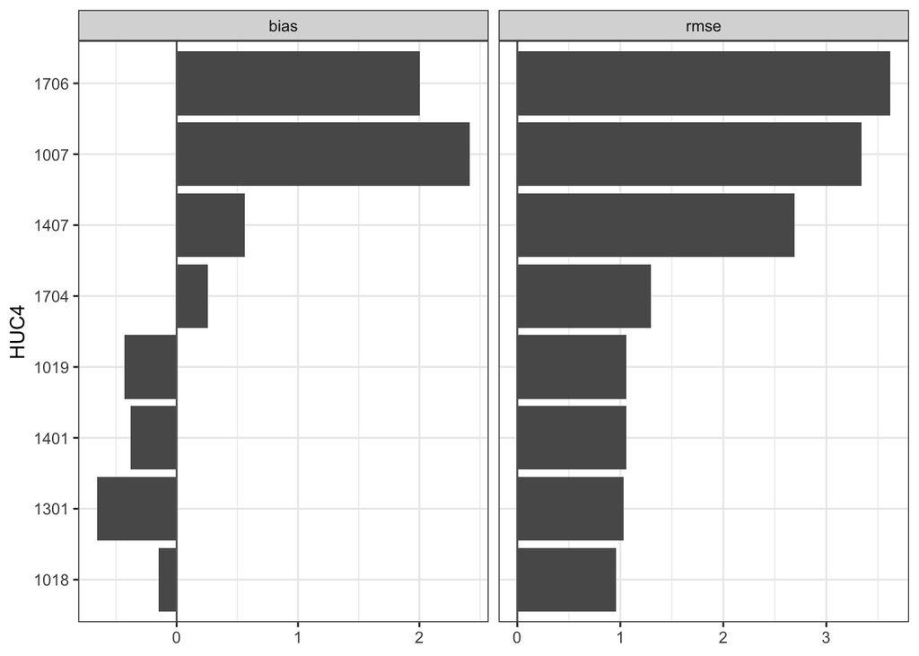

```r
huc4_order <- evals_test_huc4 %>%
  arrange(rmse) %>%
  pull(HUC4)

evals_test_huc4 %>%
  mutate(HUC4 = factor(HUC4, levels = huc4_order)) %>%
  pivot_longer(c(rmse, bias), names_to = "metric", values_to = "value") %>%
  ggplot(aes(x = HUC4, y = value)) +
  geom_col() +
  geom_hline(yintercept = 0, color = "grey40") +
  coord_flip() +
  facet_wrap(~metric, scales = "free_x") +
  labs(x = "HUC4", y = NULL) +
  theme_bw()
```

```r
states <- states(progress_bar = FALSE) %>%
  filter(STUSPS %in% c("CO", "WY", "UT", "ID", "MT", "NM"))
states_union <- states %>% st_union()

wbd_gdb <- download_wbd(outdir = "aquamatch_files/wbd_national")
```

```
## Extracting data ...
```

[output not shown]

```
## WBD data extracted to: aquamatch_files/wbd_national/WBD_National_GDB/WBD_National_GDB.gdb
```

```r
huc4_layer <- st_layers(wbd_gdb)$name %>%
  keep(~ grepl("HU4$", ., ignore.case = TRUE))

HUC4s <- st_read(wbd_gdb, layer = huc4_layer, quiet = TRUE) %>%
  rename_with(tolower) %>%
  # WBD ships with Z values and a compound CRS (NAD83 + NAVD88 height);
  # transforming a 2D CRS into that compound CRS silently breaks (no vertical
  # grid to invent a Z), so drop Z here - horizontal datum is then plain NAD83
  st_zm(drop = TRUE, what = "ZM")

# standardize the geometry column name to "geometry" (FileGDB layers are
# often read in with the geometry column named "shape")
geom_col <- attr(HUC4s, "sf_column")
if (geom_col != "geometry") {
  names(HUC4s)[names(HUC4s) == geom_col] <- "geometry"
  st_geometry(HUC4s) <- "geometry"
}

# reset (not transform) the CRS now that only the horizontal NAD83 datum
# remains, matching states_union - no reprojection needed
st_crs(HUC4s) <- st_crs(states_union)
# st_make_valid() is by far the slowest step here (a handful of the WBD's
# 245 national HU4 polygons are topologically invalid, and validating fixes
# them all), so cheaply narrow to candidates near our AOI *before* validating
# rather than after. A spatial-index filter (st_filter(), `[`) would do that,
# but it invokes the same topology engine as st_make_valid() and errors on
# this dataset's invalid geometries - so instead compare each feature's own
# bounding box (plain coordinate min/max, no topology needed) against the
# AOI's bounding box.
aoi_bbox <- st_bbox(states_union)
feat_bboxes <- map(st_geometry(HUC4s), st_bbox)
near_aoi <- map_lgl(feat_bboxes, ~ !(.x["xmax"] < aoi_bbox["xmin"] ||
                                     .x["xmin"] > aoi_bbox["xmax"] ||
                                     .x["ymax"] < aoi_bbox["ymin"] ||
                                     .x["ymin"] > aoi_bbox["ymax"]))

# validate only those candidates, then do the precise (topological) filter
# down to the HUC4's that actually touch our 6-state AOI, and attach the
# test-set metrics by HUC4 code
huc4_map <- HUC4s[near_aoi, ] %>%
  st_make_valid() %>%
  st_filter(states_union) %>%
  select(huc4, geometry) %>%
  left_join(evals_test_huc4, by = c("huc4" = "HUC4"))
```